主题 明暗

Generated by [Answer me with HTML](https://github.com/QingYunA/answer-me-with-html) 0.5.10 · 2026-10-30 23:26 · [★ Star on GitHub](https://github.com/QingYunA/answer-me-with-html)

# gptr v0.4 · T02 正式实验报告

正式收集完成，回放兼容性见后文

**实验计划**0.4.0-draft.4**更新时间UTC**2026-10-30T23:52:41+00:00

A

## 当前结论与研究范围

正式收集完成，回放兼容性见后文

计划内真实尝试已记录6/6次。 另有可用性补测2次；有效真实试验共6次。 标准执行对照已完成30/30次。 当前全部已记录执行中，36/38次通过检查。

本页汇总原始正式记录及同一冻结配置的额度补测，不混入预跑。 真实模型、参考计算和捕获轨迹回放分别统计。 时长中位数只计算通过检查的执行，失败数量同时列出。

B

## 数据与实验设计

真实数据来自 METABRIC 乳腺癌队列，共2509位患者、7个变量。 原始公开文件为408387字节的临床文本表。 准备后的 RDS 为173149字节（约0.000173 GB）。 质控后的共同分析队列为1874人，其中1089个死亡事件。 数据来源与转换记录 · 本地 RDS

| 条件 | 冻结内容 |
| --- | --- |
| 模型与推理 | gpt-6.1-sol / low |
| 数据文件大小 | 173149字节 |
| 并行任务数 | 1 |
| 数据SHA-256 | `14834db35e5b4e84917c47174ff1a38a9914dc73beb81d0a2d2ce35572d40b5f` |

A1使用gptr常驻R会话；C1使用同模型的普通R脚本与文件。 A2经过实际gptr循环回放，C2每轮请求恢复状态，C3批量执行。 三轮请求覆盖数据审计、主要分析和稳健性验证。 完整清单保留实际数据规模、来源与环境。

C

## 分组时长与正确性

| 组别 / 来源 | 通过 / 已执行 | 成功时长中位数（秒） | 成功时长范围（秒） |
| --- | --- | --- | --- |
| A1 / live | 3 / 4 | 154.184 | 142.208—175.980 |
| A2 / canonical | 10 / 10 | 11.310 | 11.060—12.637 |
| C1 / live | 3 / 4 | 124.794 | 117.870—135.629 |
| C2 / canonical | 10 / 10 | 3.106 | 3.036—3.388 |
| C3 / canonical | 10 / 10 | 1.427 | 1.371—1.681 |

**真实模型执行：成功时长中位数。**

**数据**

| A1 / live | 154.184秒 |
| --- | --- |
| C1 / live | 124.794秒 |

**计算与回放对照：成功时长中位数。**

[figure not shown]

**数据**

| A2 / canonical | 11.31秒 |
| --- | --- |
| C2 / canonical | 3.106秒 |
| C3 / canonical | 1.427秒 |

样本未收齐时，这些数字仅表示当前进度。 少量真实重复只能用于探索性比较，不能直接推断因果。

D

## 真实试验的读取与工具调用

| 试验 | 状态 | 原始数据加载次数 | 加载耗时（毫秒） | R执行数 | 全部可见工具数 |
| --- | --- | --- | --- | --- | --- |
| A1-1 | ✓ | 1 | 3 | 8 | 20 |
| C1-1 | ✓ | 4 | 12 | 4 | 9 |
| A1-2 | ✓ | 1 | 2 | 6 | 14 |
| C1-2 | ✓ | 4 | 9 | 4 | 9 |
| A1-3 | error | 1 | 2 | 0 | 1 |
| C1-3 | error | 0 | 0 | 0 | 0 |
| A1-4（额度补测） | ✓ | 1 | 3 | 5 | 15 |
| C1-4（额度补测） | ✓ | 3 | 8 | 3 | 8 |

RDS读取耗时包含反序列化，不等于纯磁盘传输时间。 R执行数与全部可见工具数是不同指标。 CLI内部未公开的模型轮次、请求次数与美元费用保留为未知。

E

## A1三轮请求的完整时间线

选择当前成功试验中的中间一例：A1-2。

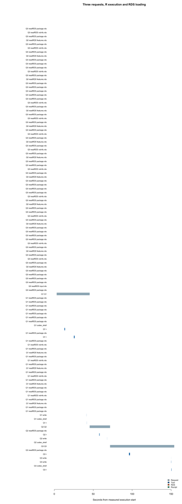

数值记录 · 检查结果 请求、工具和读取区间存在重叠，不能直接相加。 图中未归属的时间不能直接解释为纯模型思考。

F

## C1三轮请求的完整时间线

选择当前成功试验中的中间一例：C1-2。

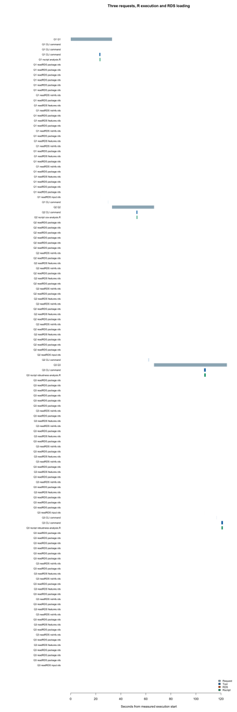

数值记录 · 检查结果 请求、工具和读取区间存在重叠，不能直接相加。 图中未归属的时间不能直接解释为纯模型思考。

G

## 回放兼容性、失败与查证

三条成功 A1 轨迹均未通过纯 R 回放兼容检查。 其中补测轨迹遗漏由其他工具写出的 research-report.md。 这不改变原始真实运行的正确性，但不能计作有效 fake 回放。 捕获轨迹只有通过干净环境验证，才会转为fake回复。 标准A2与捕获轨迹回放使用不同的来源标签。

- trajectory-1：未通过兼容验证。记录
- trajectory-2：未通过兼容验证。记录
- trajectory-4：未通过兼容验证。记录
- A1-3：服务额度阻断，消耗13.629秒。
- C1-3：服务额度阻断，消耗2.148秒。

额度失败与补测均保留。补测未替换原始尝试，也不混入预跑。 补测及后续回放记录

逐次统计 · 完整结果

下载、准备、独立检查和绘图位于正式计时之外。 正式任务完成后，先简报和更新HTML，再进入下一个任务。